# Examples of wrangling GSS data

Gary Lupyan

10/19/2021

```r
library(foreign)
library(Hmisc)
library(sjmisc)
library(tidyverse)
library(ggplot2)
library(DT)
```

# Load in data

We’re loading in the SPSS-formatted data from GSS year 2018. Need foreign::spss.get to read the data

# Two things to watch out for when importing data

## Data types

Whenever we’re loading in data from external sources, especially data as complex as the GSS, we need to make sure that we’re importing what we think we’re importing. Let’s look at a couple variables and see what kind of errors we could accidentally make

Hmm.. what’s going on?

```r
summary(gss$age)
```

```
##          18          19          20          21          22          23
##          22          26          15          27          40          29
##          24          25          26          27          28          29
##          38          43          31          39          45          43
##          30          31          32          33          34          35
##          50          34          43          42          65          40
##          36          37          38          39          40          41
##          40          43          38          55          41          40
##          42          43          44          45          46          47
##          40          39          40          29          42          30
##          48          49          50          51          52          53
##          33          31          37          41          29          48
##          54          55          56          57          58          59
##          35          48          50          39          37          46
##          60          61          62          63          64          65
##          46          39          24          37          33          39
##          66          67          68          69          70          71
##          36          27          39          41          45          33
##          72          73          74          75          76          77
##          22          20          29          23          19          28
##          78          79          80          81          82          83
##          11           9          12           9          12           7
##          84          85          86          87          88 89 OR OLDER
##          10          12          14           5           8          29
##        NA's
##           7
```

Uh huh… how do we fix it? What about this? Let’s just assume that those >89 are 90. They’re not, but it’s better than just leaving them out of the analysis, so….

```r
gss$age_recoded = gss$age %>%
  fct_recode("90"="89 OR OLDER") %>%
  as.numeric

mean(gss$age_recoded,na.rm=TRUE)
```

```
## [1] 31.97138
```

Ok.. mean is 32.. seems reasonable? Is it correct though? Let’s look at a histogram. What do you notice?

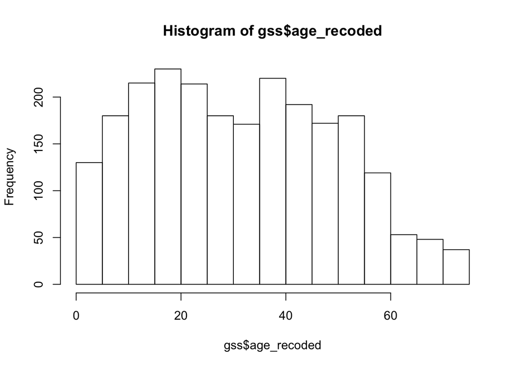

```r
hist(gss$age_recoded)
```

How do we fix this?

```r
gss$age_recoded = gss$age %>%
  fct_recode("90"="89 OR OLDER") %>%
  as.character %>%
  as.numeric

mean(gss$age_recoded,na.rm=TRUE)
```

```
## [1] 48.98377
```

What’s the mean and median income of participants younger than 25 in 2018 dollars? To get 2018 dollars (where these data are from), multiply realrinc (1986 dollars) by 2.29.

```r
gss$age_recoded = gss$age %>%
  fct_recode("90"="89 OR OLDER") %>%
  as.character %>%
  as.numeric

gss <- gss %>% mutate(realrinc = as.numeric(as.character(realrinc)))
gss <- gss %>% mutate(realrinc_2016 = realrinc*2.29)
```

How many participants are there in this dataset who’re younger than 25? Break it down by the participant’s gender (`sex`). Do you notice anything about the mean vs. median for males vs. females? What is this telling you?

Solution

```r
gss %>% filter(age_recoded<25) %>%
  summarize(realrinc_2016_mean = mean(realrinc_2016,na.rm=TRUE),realrinc_2016_med = median(realrinc_2016,na.rm=TRUE),n=n())
```

```
##   realrinc_2016_mean realrinc_2016_med   n
## 1           16441.63           9356.94 197
```

## Factor levels

The variable `happy` contains participant’s responses to this question: `Taken all together, how would you say things are these days--would you say that you are very happy, pretty happy, or not too happy?`

It’s coded as those three levels

```r
levels(gss$happy)
```

```
## [1] "VERY HAPPY"    "PRETTY HAPPY"  "NOT TOO HAPPY"
```

Let’s look at respondents’ happiness as a function of self-reported health (`health`)

```r
gss %>% drop_na(health) %>% group_by(health) %>% summarize(happy = mean(as.numeric(happy),na.rm=TRUE))
```

```
## # A tibble: 4 × 2
##   health    happy
##   <fct>     <dbl>
## 1 EXCELLENT  1.56
## 2 GOOD       1.85
## 3 FAIR       2.02
## 4 POOR       2.35
```

See the problem?

```r
levels(gss$happy)
```

```
## [1] "VERY HAPPY"    "PRETTY HAPPY"  "NOT TOO HAPPY"
```

Let’s fix it:

```r
gss$happy_rev <- fct_rev(gss$happy)
```

# Do people know that the earth goes around the sun?

Ok, let’s switch gearts a bit. Let’s look at some relationships between `degree` (participant’s education level) and their knowledge of whether the earth goes around the sun or the sun goes around the earth (`earthsun`)

## Contingency tables using base R

The first way we can do this is by using contingency tables found in the base package which by default will show us frequencies:

```r
gss %>% xtabs(~degree+earthsun,data=.)
```

```
##                 earthsun
## degree           Earth around sun Sun around earth
##   LT HIGH SCHOOL               77               44
##   HIGH SCHOOL                 413              166
##   JUNIOR COLLEGE               57               26
##   BACHELOR                    192               31
##   GRADUATE                     97               14
```

or more usefully, proportions (notice how we’re piping in the `xtabs` output into `prop.table`)

```r
gss %>% xtabs(~degree+earthsun,data=.) %>% prop.table(margin=1) %>% round(2)
```

```
##                 earthsun
## degree           Earth around sun Sun around earth
##   LT HIGH SCHOOL             0.64             0.36
##   HIGH SCHOOL                0.71             0.29
##   JUNIOR COLLEGE             0.69             0.31
##   BACHELOR                   0.86             0.14
##   GRADUATE                   0.87             0.13
```

## Contingency tables using `sjmisc`

Here’s what the same tabulation looks like using the `sjmisc` package which provides us some nice additional features:

```r
gss %>% flat_table(degree,earthsun)
```

```
##                earthsun Earth around sun Sun around earth
## degree
## LT HIGH SCHOOL                        77               44
## HIGH SCHOOL                          413              166
## JUNIOR COLLEGE                        57               26
## BACHELOR                             192               31
## GRADUATE                              97               14
```

..and proportions:

```r
gss %>% flat_table(degree,earthsun,margin=c("row"),digits=0) #the digits argument is the number of significant digits
```

```
##                earthsun Earth around sun Sun around earth
## degree
## LT HIGH SCHOOL                        64               36
## HIGH SCHOOL                           71               29
## JUNIOR COLLEGE                        69               31
## BACHELOR                              86               14
## GRADUATE                              87               13
```

`sjmisc` has additional grouping functions that allow us to split a variable into equal groups. Let’s do this for `degree`. Note that we need to first convert it to numeric.

```r
gss %>% transform(degree=as.numeric(degree)) %>%
  split_var(degree,n=3,val.labels = c("Lowest tertile","Middle tertle", "Highest tertile")) %>%
  flat_table(degree_g,earthsun,margin=c("row"),digits=1)
```

```
##                 earthsun Earth around sun Sun around earth
## degree_g
## Lowest tertile                       63.6             36.4
## Middle tertle                        71.3             28.7
## Highest tertile                      83.0             17.0
```

## Contingency tables using `dplyr`

Here’s what a basic contingency table looks like with `dplyr`

```r
gss %>% group_by(degree,earthsun) %>% summarize(n=n())
```

```
## # A tibble: 15 × 3
## # Groups:   degree [5]
##    degree         earthsun             n
##    <fct>          <fct>            <int>
##  1 LT HIGH SCHOOL Earth around sun    77
##  2 LT HIGH SCHOOL Sun around earth    44
##  3 LT HIGH SCHOOL <NA>               141
##  4 HIGH SCHOOL    Earth around sun   413
##  5 HIGH SCHOOL    Sun around earth   166
##  6 HIGH SCHOOL    <NA>               599
##  7 JUNIOR COLLEGE Earth around sun    57
##  8 JUNIOR COLLEGE Sun around earth    26
##  9 JUNIOR COLLEGE <NA>               113
## 10 BACHELOR       Earth around sun   192
## 11 BACHELOR       Sun around earth    31
## 12 BACHELOR       <NA>               242
## 13 GRADUATE       Earth around sun    97
## 14 GRADUATE       Sun around earth    14
## 15 GRADUATE       <NA>               136
```

Let’s get rid of those NAs:

```r
gss %>% group_by(degree,earthsun) %>% drop_na(degree,earthsun) %>% summarize(n=n())
```

```
## # A tibble: 10 × 3
## # Groups:   degree [5]
##    degree         earthsun             n
##    <fct>          <fct>            <int>
##  1 LT HIGH SCHOOL Earth around sun    77
##  2 LT HIGH SCHOOL Sun around earth    44
##  3 HIGH SCHOOL    Earth around sun   413
##  4 HIGH SCHOOL    Sun around earth   166
##  5 JUNIOR COLLEGE Earth around sun    57
##  6 JUNIOR COLLEGE Sun around earth    26
##  7 BACHELOR       Earth around sun   192
##  8 BACHELOR       Sun around earth    31
##  9 GRADUATE       Earth around sun    97
## 10 GRADUATE       Sun around earth    14
```

Let’s convert to proportions:

```r
gss %>% group_by(degree,earthsun) %>% drop_na(degree,earthsun) %>% summarize(n=n()) %>%
    mutate(proportion = n / sum(n))
```

```
## # A tibble: 10 × 4
## # Groups:   degree [5]
##    degree         earthsun             n proportion
##    <fct>          <fct>            <int>      <dbl>
##  1 LT HIGH SCHOOL Earth around sun    77      0.636
##  2 LT HIGH SCHOOL Sun around earth    44      0.364
##  3 HIGH SCHOOL    Earth around sun   413      0.713
##  4 HIGH SCHOOL    Sun around earth   166      0.287
##  5 JUNIOR COLLEGE Earth around sun    57      0.687
##  6 JUNIOR COLLEGE Sun around earth    26      0.313
##  7 BACHELOR       Earth around sun   192      0.861
##  8 BACHELOR       Sun around earth    31      0.139
##  9 GRADUATE       Earth around sun    97      0.874
## 10 GRADUATE       Sun around earth    14      0.126
```

Notice that the data are in a `long` format. This is exactly what we want for graphing and statistical analyses, but if you want a more readable table, just pivot it like so:

```r
gss %>% group_by(degree,earthsun) %>% drop_na(degree,earthsun) %>%
    summarize(n=n()) %>% mutate(proportion = n / sum(n)) %>%
  select(-n) %>% #get rid of the number of observations column since we're using proportions here
    pivot_wider(names_from=earthsun,values_from=proportion)
```

```
## # A tibble: 5 × 3
## # Groups:   degree [5]
##   degree         `Earth around sun` `Sun around earth`
##   <fct>                       <dbl>              <dbl>
## 1 LT HIGH SCHOOL              0.636              0.364
## 2 HIGH SCHOOL                 0.713              0.287
## 3 JUNIOR COLLEGE              0.687              0.313
## 4 BACHELOR                    0.861              0.139
## 5 GRADUATE                    0.874              0.126
```

## Human evolution, politics, education

```r
gss %>% flat_table(polviews,evolved,margin=c("row"),digits=1)
```

```
##                      evolved True False
## polviews
## EXTREMELY LIBERAL            76.7  23.3
## LIBERAL                      83.1  16.9
## SLIGHTLY LIBERAL             66.0  34.0
## MODERATE                     54.8  45.2
## SLGHTLY CONSERVATIVE         52.0  48.0
## CONSERVATIVE                 35.3  64.7
## EXTRMLY CONSERVATIVE         36.8  63.2
```

Let’s see how the likelihood of endorsing human evolution is affected by education (`degree`):

```r
gss %>% group_by(degree) %>% drop_na(degree,evolved) %>% summarize(evolved=round(mean(evolved=="True",na.rm=TRUE),2),n=n())
```

```
## # A tibble: 5 × 3
##   degree         evolved     n
##   <fct>            <dbl> <int>
## 1 LT HIGH SCHOOL    0.4     47
## 2 HIGH SCHOOL       0.53   258
## 3 JUNIOR COLLEGE    0.64    45
## 4 BACHELOR          0.64   117
## 5 GRADUATE          0.6     57
```

Now let’s see whether education has a differential effect for people of various political orientations. For simplicity let’s dichotomize education into respondents with a college degree or above, and those below a college degree:

```r
gss %>% drop_na(polviews,degree,evolved) %>%
    mutate(college_or_more = (as.numeric(degree) > 3)) %>%
    group_by(polviews,college_or_more) %>%
    summarize(humans_evolved=round(mean(evolved=="True",na.rm=TRUE),2),n=n()) %>%
  datatable(options = list(pageLength = 20)) #check this out in a browser!
```

|  | polviews | college_or_more | humans_evolved | n |
| --- | --- | --- | --- | --- |
| 1 | EXTREMELY LIBERAL | False | 0.57 | 14 |
| 2 | EXTREMELY LIBERAL | True | 0.94 | 16 |
| 3 | LIBERAL | False | 0.71 | 28 |
| 4 | LIBERAL | True | 0.94 | 31 |
| 5 | SLIGHTLY LIBERAL | False | 0.68 | 38 |
| 6 | SLIGHTLY LIBERAL | True | 0.6 | 15 |
| 7 | MODERATE | False | 0.53 | 133 |
| 8 | MODERATE | True | 0.58 | 53 |
| 9 | SLGHTLY CONSERVATIVE | False | 0.49 | 49 |
| 10 | SLGHTLY CONSERVATIVE | True | 0.58 | 26 |

[output cut: 4 more lines]

**(notice the small Ns in some cells)**

This is the kind of data that’s perfect for graphing to look at interactions. But we’re examining it in table form, we can pivot it to wide and make a difference column, e.g

```r
gss %>% drop_na(polviews,degree,evolved) %>%
    mutate(college_or_more = (as.numeric(degree) > 3)) %>%
    group_by(polviews,college_or_more) %>%
    summarize(humans_evolved=mean(evolved=="True",na.rm=TRUE)) %>%
    pivot_wider(names_from=college_or_more,values_from=humans_evolved) %>% rename("college_or_more" = `TRUE`, "lt_college" = `FALSE`) %>%
    mutate(evolution_diff = college_or_more - lt_college)
```

```
## # A tibble: 7 × 4
## # Groups:   polviews [7]
##   polviews             lt_college college_or_more evolution_diff
##   <fct>                     <dbl>           <dbl>          <dbl>
## 1 EXTREMELY LIBERAL         0.571           0.938         0.366
## 2 LIBERAL                   0.714           0.935         0.221
## 3 SLIGHTLY LIBERAL          0.684           0.6          -0.0842
## 4 MODERATE                  0.534           0.585         0.0511
## 5 SLGHTLY CONSERVATIVE      0.490           0.577         0.0871
## 6 CONSERVATIVE              0.404           0.25         -0.154
## 7 EXTRMLY CONSERVATIVE      0.375           0.333        -0.0417
```

What does a regression model look like in the tidyverse? Simple! Let’s test for the main effects and interaction of `polviews` and `degree` on `evolution` using logistic regression (because our outcome variable is binary). We’re going to use `scale` to center the variables. We don’t need to explicitly use `drop_na` because glm will automatically drop missing values.

```r
gss %>% glm(I(evolved=="True")~scale(as.numeric(polviews))*scale(as.numeric(degree)),data=.,family=binomial) %>% summary
```

```
##
## Call:
## glm(formula = I(evolved == "True") ~ scale(as.numeric(polviews)) *
##     scale(as.numeric(degree)), family = binomial, data = .)
##
## Deviance Residuals:
##     Min       1Q   Median       3Q      Max
## -2.2251  -1.1399   0.5613   1.1060   1.9199
##
## Coefficients:
##                                                       Estimate Std. Error
## (Intercept)                                            0.27419    0.09536
## scale(as.numeric(polviews))                           -0.58379    0.10311
## scale(as.numeric(degree))                              0.20776    0.09974
## scale(as.numeric(polviews)):scale(as.numeric(degree)) -0.31711    0.10670
##                                                       z value Pr(>|z|)
## (Intercept)                                             2.875  0.00404 **
## scale(as.numeric(polviews))                            -5.662  1.5e-08 ***
## scale(as.numeric(degree))                               2.083  0.03725 *
## scale(as.numeric(polviews)):scale(as.numeric(degree))  -2.972  0.00296 **
## ---
## Signif. codes:  0 '***' 0.001 '**' 0.01 '*' 0.05 '.' 0.1 ' ' 1
##
## (Dispersion parameter for binomial family taken to be 1)
##
##     Null deviance: 695.00  on 506  degrees of freedom
## Residual deviance: 640.54  on 503  degrees of freedom
##   (1841 observations deleted due to missingness)
## AIC: 648.54
##
## Number of Fisher Scoring iterations: 4
```

# Now it’s your turn!

You can look up info on the variables at https://gssdataexplorer.norc.org/variables/vfilter If you just need to quickly look up the description of the variable use `head(gss$var_name)` or summary(gss$var_name) to list its factors (which will be listed in order). Note that when the data were imported from SPSS, all variables were imported as factors, hence the need to convert to numeric as needed.

## Children and happiness

Are people with children (`childs!=0`) happier (`happy`) than people without children? Does this relationship depend on the respondent’s gender? (`sex`) Their age? (`age`)?

Note Feel free to bin age into discrete groups (20-30, 31-40 etc.). The sjmisc package has nice functions for this. See the cheat sheet.

## Income and happiness

What’s the relationship between respondent’s income (`realrinc`) and happiness (`happy`)? Use `sjmisc::split_var` to bin income into quintiles (i.e., 5 equal groups). How does this relationship vary for people who have a college degree or higher vs. people who don’t?

**Tip** Remember to convert income to numeric using `as.numeric(as.character(realrinc)))`

**Tip** `realrinc` is income in 1986 dollars. To convert to 2018 dollars, multiply by 2.29. Also make sure you interpret the value of `happy` correctly.

## Politics and cynicism

Have a look at the variable `helpful`. What’s the relationship between `helpful` and political party affiliation (`partyid`)? Notice something funny there) What about its relationship with religiosity (`god`)? Age (`age`)?

Since it’s hard to interpret “DEPENDS” as an answer, let’s focus on whether people are helpful or looking out for selves (the first two options).

## Individual income, family income, and marital happiness

The data includes not only the respondent’s income (`realrinc`), but also the family income (`realinc`) This allows you to figure out how much other members of the family (typically the spouse) is earning. Do respondents whose income is a larger proportion of the family income have a different marital satisfaction (`hapmar`)?